# What can you do for more salary?

# Business Understanding

I want to explore the factors and dynamics which are related to salary amount. Findings from this study help to someone who wants to gains more salary. I determined below questions to reach the findings.

1. Which countries are more promosing in terms of salary?
2. Is the relationship between salary and satisfaction really linear? And how does it change according to region?
3. Do we need more degree to earn more money?
4. Does a woman have same or similar opportunity in different countries?
5. Which countries are more promosing to earn more money based on our experience?

# Data Exploration

I wanted to understand nature of data therefore I explored the data set

```python
#Importar libraries
import numpy as np
import pandas as pd
import matplotlib.pyplot as plt
import seaborn as sns
import warnings
warnings.simplefilter("ignore")

%matplotlib inline
```

```python
#Load data
survey_results_2020 = pd.read_csv('developer_survey_2020/survey_results_public.csv')
survey_question_2020 = pd.read_csv('developer_survey_2020/survey_results_schema.csv')
```

```python
survey_results_2020.head()
```

|  | Respondent | MainBranch | Hobbyist | Age | Age1stCode | CompFreq | CompTotal | ConvertedComp | Country | CurrencyDesc | ... | SurveyEase | SurveyLength | Trans | UndergradMajor | WebframeDesireNextYear | WebframeWorkedWith | WelcomeChange | WorkWeekHrs | YearsCode | YearsCodePro |
| --- | --- | --- | --- | --- | --- | --- | --- | --- | --- | --- | --- | --- | --- | --- | --- | --- | --- | --- | --- | --- | --- |
| 0 | 1 | I am a developer by profession | Yes | NaN | 13 | Monthly | NaN | NaN | Germany | European Euro | ... | Neither easy nor difficult | Appropriate in length | No | Computer science, computer engineering, or sof... | ASP.NET Core | ASP.NET;ASP.NET Core | Just as welcome now as I felt last year | 50.0 | 36 | 27 |
| 1 | 2 | I am a developer by profession | No | NaN | 19 | NaN | NaN | NaN | United Kingdom | Pound sterling | ... | NaN | NaN | NaN | Computer science, computer engineering, or sof... | NaN | NaN | Somewhat more welcome now than last year | NaN | 7 | 4 |
| 2 | 3 | I code primarily as a hobby | Yes | NaN | 15 | NaN | NaN | NaN | Russian Federation | NaN | ... | Neither easy nor difficult | Appropriate in length | NaN | NaN | NaN | NaN | Somewhat more welcome now than last year | NaN | 4 | NaN |
| 3 | 4 | I am a developer by profession | Yes | 25.0 | 18 | NaN | NaN | NaN | Albania | Albanian lek | ... | NaN | NaN | No | Computer science, computer engineering, or sof... | NaN | NaN | Somewhat less welcome now than last year | 40.0 | 7 | 4 |
| 4 | 5 | I used to be a developer by profession, but no... | Yes | 31.0 | 16 | NaN | NaN | NaN | United States | NaN | ... | Easy | Too short | No | Computer science, computer engineering, or sof... | Django;Ruby on Rails | Ruby on Rails | Just as welcome now as I felt last year | NaN | 15 | 8 |

5 rows × 61 columns

```python
survey_question_2020.head()
```

|  | Column | QuestionText |
| --- | --- | --- |
| 0 | Respondent | Randomized respondent ID number (not in order ... |
| 1 | MainBranch | Which of the following options best describes ... |
| 2 | Hobbyist | Do you code as a hobby? |
| 3 | Age | What is your age (in years)? If you prefer not... |
| 4 | Age1stCode | At what age did you write your first line of c... |

```python
plot_data1= survey_results_2020['EdLevel'].value_counts()/survey_results_2020.shape[0]
```

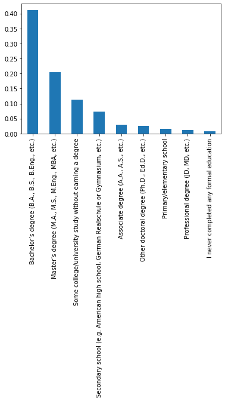

```python
plot_data1.plot(kind="bar")
plt.show()
```

Formal education level can be important factor to earn more money therefore it should be further exploreed.

```python
plot_data2= survey_results_2020['Country'].value_counts()/survey_results_2020.shape[0]
```

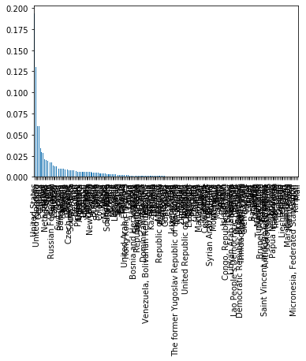

```python
plot_data2.plot(kind="bar")
plt.show()
```

Country columns is really crowded so it should be reducted to get a meaningful information. Dividing to region that consists of some countries will be more reasonable.

```python
plot_data3= survey_results_2020['Gender'].value_counts()/survey_results_2020.shape[0]
```

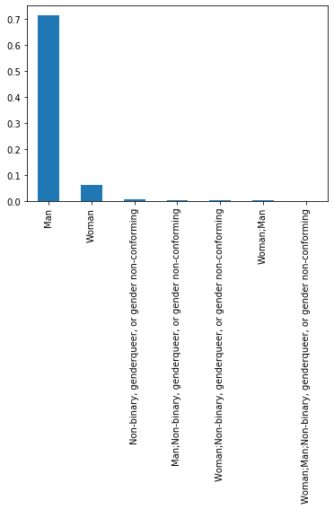

```python
plot_data3.plot(kind="bar")
plt.show()
```

Genders other than man and woman can be ignored. I am curious about salary amount based on gender as a woman.

```python
plot_data4= survey_results_2020['JobSat'].value_counts()/survey_results_2020.shape[0]
```

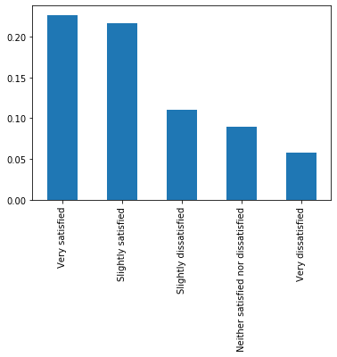

```python
plot_data4.plot(kind="bar")
plt.show()
```

Most of people consider that the more money provides the more satisfied person. I will investigate this myth.

# Answering Questions and Analysis

I explored and arranged/cleaned data set to reach the answers which is presented above.

```python
def drop_row(df):
    missing_rows = (df.isnull().sum(axis=1))
    df = df[missing_rows<1]
    return df
```

I arranged data set for my questions and I used only relevant feature for each questions. Also, I dropped the rows that have missing valued for this subset of data.

```python
def region(df):
    europe = [ 'United Kingdom', 'Germany', 'France','Netherlands', 'Iceland', 'Norway','Denmark','Ireland',
          'Sweden', 'Luxembourg', 'Switzerland', 'Austria','Finland',
          'Belgium', 'Liechtenstein', 'Spain', 'Italy','Poland']

    america = ['United States', 'Canada']

    far_east = ['India', 'China', 'Japan', 'Thailand', 'Singapore', 'Hong Kong', 'South Korea', 'Taiwan', 'Malaysia',
            'Indonesia', 'Vietnam']

    df['Region']= df['Country'].apply(lambda x: 'Europe' if x in europe else ('America' if x in america
                                           else ('Far East'if x in far_east else 'Other')))
    return df
```

# Which countries are more promosing in terms of salary?

```python
used_columns = survey_results_2020[['ConvertedComp', 'Country', 'EdLevel', 'Gender', 'JobSat', 'YearsCodePro']]
```

```python
data_set1= used_columns[['ConvertedComp', 'Country']]
data_set1 = drop_row(data_set1)
data_set1 = region(data_set1)
data_set1 = data_set1.groupby(['Region'])['ConvertedComp'].mean().reset_index()
```

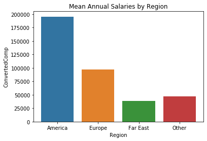

```python
sns.barplot(x = 'Region', y = 'ConvertedComp', data = data_set1).plot(legend=True)
plt.title('Mean Annual Salaries by Region')
```

According to the bar chart, we can earn more money in United States and Canada. The difference between these two contries and others is really remarkable. We can consider to work for United States and Canada.

# Is the relationship between salary and satisfaction really linear? And how does it change according to region?

```python
data_set2= used_columns[['ConvertedComp', 'Country', 'JobSat']]
data_set2 = drop_row(data_set2)
data_set2 = region(data_set2)
data_set2 = data_set2.groupby(['JobSat', 'Region'])['ConvertedComp'].mean().reset_index()
```

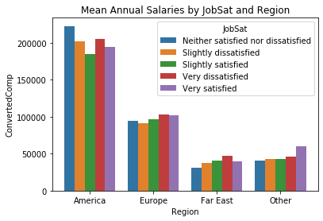

```python
sns.barplot(x = 'Region', y = 'ConvertedComp', hue= 'JobSat', data = data_set2).plot(legend=True)
plt.title('Mean Annual Salaries by JobSat and Region')
```

Most of people assumed that jos satisfaction and salary have linear relationship as I do. I want to explore this myth. However, it can said that 'very satisfied' and 'very dissatisfied' people have generally same salary. We can reconsider to earn more money.

# Do we need more degree to earn more money?

```python
data_set3= used_columns[['ConvertedComp', 'JobSat', 'EdLevel','Country']]
data_set3 = drop_row(data_set3)
data_set3 = region(data_set3)
data_set3= data_set3.groupby(['EdLevel'])['ConvertedComp'].mean().reset_index()
```

[figure not shown]

```python
sns.barplot(x = 'EdLevel', y = 'ConvertedComp', data = data_set3).plot(legend=True)
plt.title('Mean Annual Salaries by EdLevel')
```

```python
data_set3.sort_values(by='ConvertedComp', ascending = False)
```

|  | EdLevel | ConvertedComp |
| --- | --- | --- |
| 4 | Other doctoral degree (Ph.D., Ed.D., etc.) | 123078.783143 |
| 5 | Primary/elementary school | 114752.679739 |
| 1 | Bachelor’s degree (B.A., B.S., B.Eng., etc.) | 107699.872026 |
| 0 | Associate degree (A.A., A.S., etc.) | 106927.756432 |
| 2 | I never completed any formal education | 104351.616883 |
| 3 | Master’s degree (M.A., M.S., M.Eng., MBA, etc.) | 103142.720694 |
| 8 | Some college/university study without earning ... | 97946.899559 |
| 7 | Secondary school (e.g. American high school, G... | 79194.214090 |
| 6 | Professional degree (JD, MD, etc.) | 72062.004193 |

The relationship between salary and degree is really interesting. People which have higher degree like Ph. D. earn also more money. On the other hand, this relationship is notstraightforward since all higher degree does not mean higher salary. For example, people with primary/elementary school have second most average salary. It can be more reasonable to learn on the job rather that to take another high degree.

# Does a woman have same or similar opportunity in different countries?

```python
data_set4= used_columns[['ConvertedComp', 'Gender', 'Country']]
data_set4 = drop_row(data_set4)
data_set4 = region(data_set4)
data_set4 = data_set4.loc[(data_set4['Gender'] == 'Man') | (data_set4['Gender'] == 'Woman')]
data_set4 = data_set4.groupby(['Region', 'Gender'])['ConvertedComp'].mean().reset_index()
```

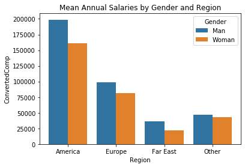

```python
sns.barplot(x = 'Region', y = 'ConvertedComp', hue= 'Gender', data = data_set4).plot(legend=True)
plt.title('Mean Annual Salaries by Gender and Region')
```

I wondered the position of woman in business as a woman. It is very soory to see the woman salary is lower than man. It can a result for all kinds of job.

# Which countries are more promosing to earn more money based on our experience?

```python
data_set5= used_columns[['YearsCodePro', 'ConvertedComp', 'Country']]
data_set5 = drop_row(data_set5)
data_set5 = region(data_set5)
data_set5 = data_set5.loc[data_set5['YearsCodePro']!='Less than 1 year']
data_set5= data_set5.loc[data_set5['YearsCodePro']!='More than 50 years']
data_set5['YearsCodePro'] = pd.to_numeric(data_set5['YearsCodePro'])
data_set5 = data_set5.groupby(['YearsCodePro', 'Region'])['ConvertedComp'].mean().reset_index()
data_set5 = data_set5.sort_values(by='YearsCodePro', ascending = True)
```

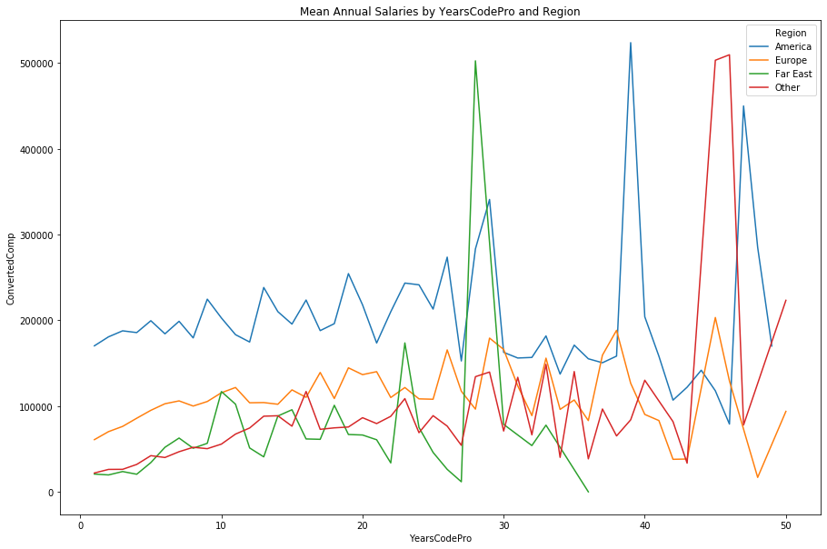

```python
plt.figure(figsize=(15,10))
sns.lineplot(x = 'YearsCodePro', y = 'ConvertedComp', hue= 'Region', data = data_set5).plot(legend=True)
plt.title('Mean Annual Salaries by YearsCodePro and Region')
```